# SC3 Clustering

[SC3 package manual](https://bioconductor.org/packages/release/bioc/vignettes/SC3/inst/doc/SC3.html)

# Introduction

Single-Cell Consensus Clustering (*SC3*) is a tool for unsupervised clustering of scRNA-seq data. SC3 achieves high accuracy and robustness by consistently integrating different clustering solutions through a consensus approach. An interactive graphical implementation makes SC3 accessible to a wide audience of users. In addition, SC3 also aids biological interpretation by identifying marker genes, differentially expressed genes and outlier cells. A manuscript describing SC3 in details is published in Nature Methods.

# SingleCellExperiment, QC and scater

SC3 is a purely clustering tool and it does not provide functions for the sequencing quality control (*QC*) or normalisation. On the contrary it is expected that these preprocessing steps are performed by a user in advance. To encourage the preprocessing, SC3 is built on top of the Bioconductor’s SingleCellExperiment class and uses functionality of scater package for *QC*.

# Start

## SC3 Input

If you already have a SingleCellExperiment object created and QCed using scater then proceed to the next chapter.

If you have a matrix containing expression data that was QCed and normalised by some other tool, then we first need to form an SingleCellExperiment object containing the data. For illustrative purposes we will use an example expression matrix provided with SC3. The dataset (yan) represents FPKM gene expression of 90 cells derived from human embryo. The authors (Yan et al.) have defined developmental stages of all cells in the original publication (ann data frame). The rows in the yan dataset correspond to genes and columns correspond to cells.

```r
library(SingleCellExperiment)
library(SC3)
library(scater)
head(ann)
```

|  | cell_type1 |
| --- | --- |
| Oocyte..1.RPKM. | zygote |
| Oocyte..2.RPKM. | zygote |
| Oocyte..3.RPKM. | zygote |
| Zygote..1.RPKM. | zygote |
| Zygote..2.RPKM. | zygote |
| Zygote..3.RPKM. | zygote |

```r
yan[1:3, 1:3]
```

|  | Oocyte..1.RPKM. | Oocyte..2.RPKM. | Oocyte..3.RPKM. |
| --- | --- | --- | --- |
| C9orf152 | 0.0 | 0.0 | 0.0 |
| RPS11 | 1219.9 | 1021.1 | 931.6 |
| ELMO2 | 7.0 | 12.2 | 9.3 |

The ann dataframe contains just cell_type1 column which correspond to the cell labels provided by authors of the original publication. Note that in general it can also contain more information about the cells, such as plate, run, well, date etc.

Now we can create a SingleCellExperiment object from yan expression matrix.

Note that SC3 requires both counts and logcounts slots to exist in the input SingleCellExperiment object. The counts slot is used for gene filtering, which is based on gene dropout rates. logcounts slot, which is supposed to contain both normalised and log-transformed expression matrix, is used in the main clustering algorithm. In the case of the yan dataset even though the counts are not available (we only have FPKM values) we can use the FPKM values for gene dropout rate calculations since FPKM normalisation does not change the dropout rate.

SC3 also requires the feature_symbol column of the rowData slot of the input SingleCellExperiment object to contain preferable feature names (genes/transcript) which will be used in the futher visualisations.

```r
# create a SingleCellExperiment object
sce <- SingleCellExperiment(
    assays = list(
        counts = as.matrix(yan),
        logcounts = log2(as.matrix(yan) + 1)
    ),
    colData = ann
)
# define feature names in feature_symbol column
rowData(sce)$feature_symbol <- rownames(sce)
# remove features with duplicated names
sce <- sce[!duplicated(rowData(sce)$feature_symbol), ]
```

scater allows a user to quickly visualize and assess any SingleCellExperiment object, for example using a PCA plot:

```r
sce <- runPCA(sce)
```

```
You're computing too large a percentage of total singular values, use a standard svd instead.
```

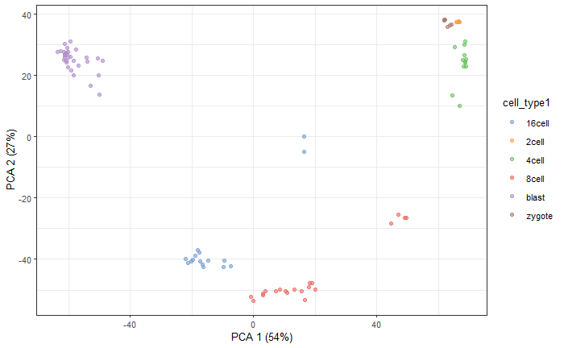

```r
plotPCA(sce, colour_by = "cell_type1")
```

## Run SC3

If you would like to explore clustering of your data in the range of ks (the number of clusters) from 2 to 4, you just need to run the main sc3 method and define the range of ks using the ks parameter (here we also ask SC3 to calculate biological features based on the identified cell clusters):

```r
sce <- sc3(sce, ks = 2:4, biology = TRUE)
```

```
Setting SC3 parameters...
Calculating distances between the cells...
Performing transformations and calculating eigenvectors...
Performing k-means clustering...
```

```
Calculating consensus matrix...
Calculating biology...
```

By default SC3 will use all but one cores of your machine. You can manually set the number of cores to be used by setting the n_cores parameter in the sc3 call.

To quickly and easily explore the SC3 solutions using an interactive Shiny application use the following method:

```r
sc3_interactive(sce)
```

```
Listening on http://127.0.0.1:6498
```

Visual exploration can provide a reasonable estimate of the number of clusters k. Once a preferable k is chosen it is also possible to export the results into an Excel file:

```r
sc3_export_results_xls(sce)
```

This will write all results to sc3_results.xls file. The name of the file can be controlled by the filename parameter.

## colData

SC3 writes all its results obtained for cells to the colData slot of the sce object by adding additional columns to it. This slot also contains all other cell features calculated by the scater package either automatically during the sce object creation or during the calculateQCMetrics call. One can identify the SC3 results using the “sc3_” prefix:

```r
col_data <- colData(sce)
head(col_data[ , grep("sc3_", colnames(col_data))])
```

```
DataFrame with 6 rows and 6 columns
                sc3_2_clusters
                      <factor>
Oocyte..1.RPKM.              2
Oocyte..2.RPKM.              2
Oocyte..3.RPKM.              2
Zygote..1.RPKM.              2
Zygote..2.RPKM.              2
Zygote..3.RPKM.              2
                sc3_3_clusters
                      <factor>
Oocyte..1.RPKM.              2
Oocyte..2.RPKM.              2
Oocyte..3.RPKM.              2
Zygote..1.RPKM.              2
Zygote..2.RPKM.              2
Zygote..3.RPKM.              2
                sc3_4_clusters
                      <factor>
Oocyte..1.RPKM.              2
Oocyte..2.RPKM.              2
Oocyte..3.RPKM.              2
Zygote..1.RPKM.              2
Zygote..2.RPKM.              2
Zygote..3.RPKM.              2
                sc3_2_log2_outlier_score
                               <numeric>
Oocyte..1.RPKM.                        0
Oocyte..2.RPKM.                        0
Oocyte..3.RPKM.                        0
Zygote..1.RPKM.                        0
Zygote..2.RPKM.                        0
Zygote..3.RPKM.                        0
                sc3_3_log2_outlier_score
                               <numeric>
Oocyte..1.RPKM.                  2.79513
Oocyte..2.RPKM.                  2.83115
Oocyte..3.RPKM.                  2.59279
Zygote..1.RPKM.                  0.00000
Zygote..2.RPKM.                  0.00000
Zygote..3.RPKM.                  0.00000
                sc3_4_log2_outlier_score
                               <numeric>
Oocyte..1.RPKM.                  2.79513
Oocyte..2.RPKM.                  2.83115
Oocyte..3.RPKM.                  2.59279
Zygote..1.RPKM.                  0.00000
Zygote..2.RPKM.                  0.00000
Zygote..3.RPKM.                  0.00000
```

Additionally, having SC3 results stored in the same slot makes it possible to highlight them during any of the scater’s plotting function call, for example:

```r
sce <- runPCA(sce)
```

```
You're computing too large a percentage of total singular values, use a standard svd instead.
```

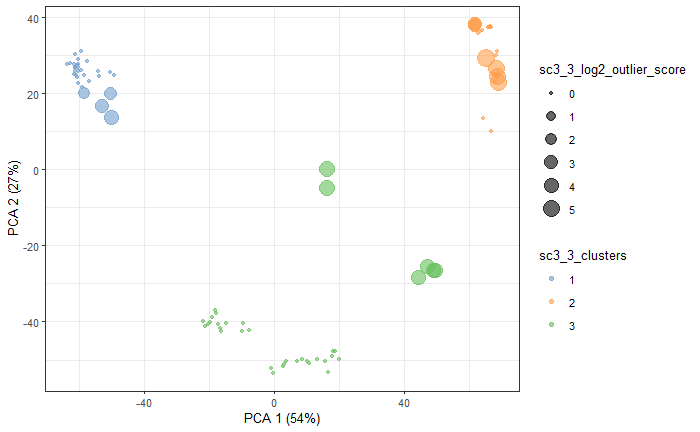

```r
plotPCA(
    sce,
    colour_by = "sc3_3_clusters",
    size_by = "sc3_3_log2_outlier_score"
)
```

## rowData

SC3 writes all its results obtained for features (genes/transcripts) to the rowData slot of the sce object by adding additional columns to it. This slot also contains all other feature values calculated by the scater package either automatically during the sce object creation or during the calculateQCMetrics call. One can identify the SC3 results using the “sc3_” prefix:

```r
row_data <- rowData(sce)
head(row_data[ , grep("sc3_", colnames(row_data))])
```

```
DataFrame with 6 rows and 13 columns
         sc3_gene_filter
               <logical>
C9orf152           FALSE
RPS11              FALSE
ELMO2               TRUE
CREB3L1             TRUE
PNMA1              FALSE
MMP2                TRUE
         sc3_2_markers_clusts
                    <numeric>
C9orf152                   NA
RPS11                      NA
ELMO2                       2
CREB3L1                     2
PNMA1                      NA
MMP2                        1
         sc3_2_markers_padj
                  <numeric>
C9orf152                 NA
RPS11                    NA
ELMO2           3.43043e-06
CREB3L1         1.00000e+00
PNMA1                    NA
MMP2            1.00000e+00
         sc3_2_markers_auroc
                   <numeric>
C9orf152                  NA
RPS11                     NA
ELMO2               0.905833
CREB3L1             0.635833
PNMA1                     NA
MMP2                0.549722
         sc3_3_markers_clusts
                    <numeric>
C9orf152                   NA
RPS11                      NA
ELMO2                       2
CREB3L1                     2
PNMA1                      NA
```

[output cut: 42 more lines]

```
             <numeric>     <numeric>
C9orf152            NA            NA
RPS11               NA            NA
ELMO2      3.33801e-06   7.88682e-10
CREB3L1    1.00000e+00   2.03905e-03
PNMA1               NA            NA
MMP2       1.00000e+00   1.00000e+00
         sc3_4_de_padj
             <numeric>
C9orf152            NA
RPS11               NA
ELMO2      1.86624e-09
CREB3L1    6.16236e-03
PNMA1               NA
MMP2       1.00000e+00
```

Because the biological features were also calculated for each k, one can find ajusted p-values for both differential expression and marker genes, as well as the area under the ROC curve values (see ?sc3_calc_biology for more information).

# Number of cells

The default settings of SC3 allow to cluster (using a single k) a dataset of 2,000 cells in about 20-30 minutes.

For datasets with more than 2,000 cells SC3 automatically adjusts some of its parameters (see below). This allows to cluster a dataset of 5,000 cells in about 20-30 minutes. The parameters can also be manually adjusted for datasets with any number of cells.

For datasets with more than 5,000 cells SC3 utilizes a hybrid approach that combines unsupervised and supervised clusterings (see below). Namely, SC3 selects a subset of cells uniformly at random, and obtains clusters from this subset. Subsequently, the inferred labels are used to train a Support Vector Machine (SVM), which is employed to assign labels to the remaining cells. Training cells can also be manually selected by providing their indeces.

# Plot Functions

SC3 also provides methods for plotting all figures from the interactive session

## Consensus Matrix

The consensus matrix is a N by N matrix, where N is the number of cells in the input dataset. It represents similarity between the cells based on the averaging of clustering results from all combinations of clustering parameters. Similarity 0 (blue) means that the two cells are always assigned to different clusters. In contrast, similarity 1 (red) means that the two cells are always assigned to the same cluster. The consensus matrix is clustered by hierarchical clustering and has a diagonal-block structure. Intuitively, the perfect clustering is achieved when all diagonal blocks are completely red and all off-diagonal elements are completely blue.

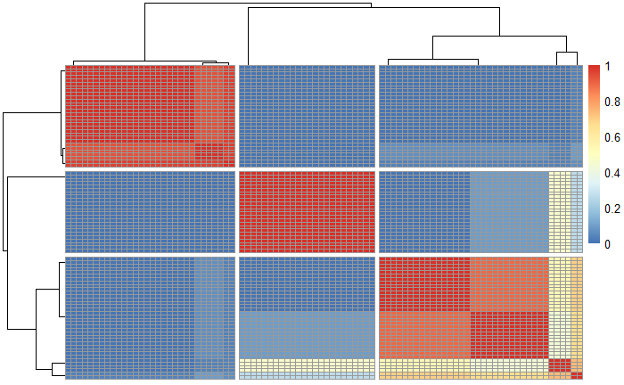

```r
sc3_plot_consensus(sce, k = 3)
```

It is also possible to annotate cells (columns of the consensus matrix) with any column of the colData slot of the sce object.

```
Provided columns 'log10_total_features' do not exist in the phenoData table!
```

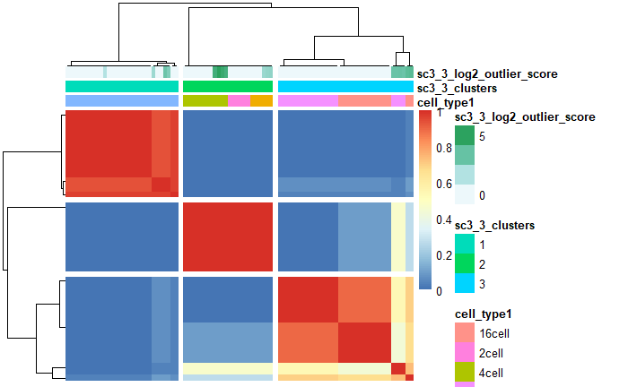

```r
sc3_plot_consensus(
    sce, k = 3,
    show_pdata = c(
        "cell_type1",
        "log10_total_features",
        "sc3_3_clusters",
        "sc3_3_log2_outlier_score"
    )
)
```

## Silhouette Plot

A silhouette is a quantitative measure of the diagonality of the consensus matrix. An average silhouette width (shown at the bottom left of the silhouette plot) varies from 0 to 1, where 1 represents a perfectly block-diagonal consensus matrix and 0 represents a situation where there is no block-diagonal structure. The best clustering is achieved when the average silhouette width is close to 1.

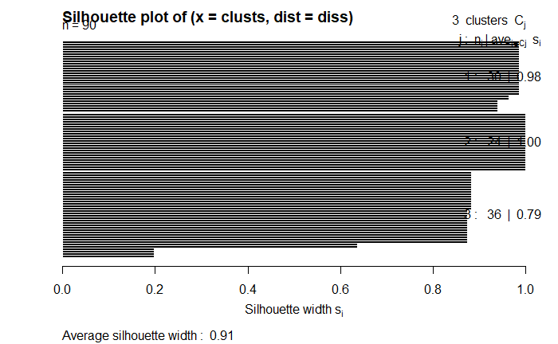

```r
sc3_plot_silhouette(sce, k = 3)
```

## Expression Matrix

The expression panel represents the original input expression matrix (cells in columns and genes in rows) after cell and gene filters. Genes are clustered by kmeans with k = 100 (dendrogram on the left) and the heatmap represents the expression levels of the gene cluster centers after log2-scaling.

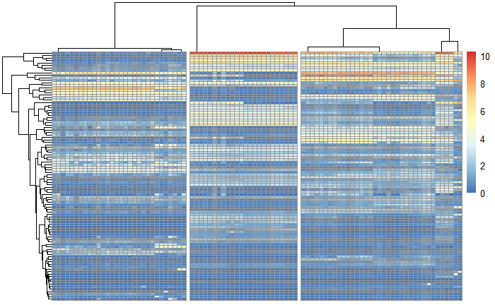

```r
sc3_plot_expression(sce, k = 3)
```

It is also possible to annotate cells (columns of the expression matrix) with any column of the colData slot of the sce object.

```
Provided columns 'log10_total_features' do not exist in the phenoData table!
```

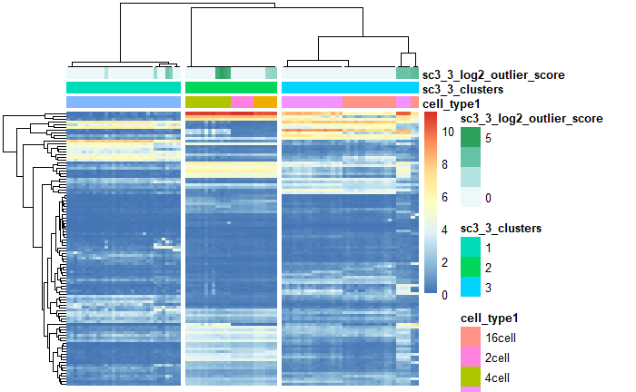

```r
sc3_plot_expression(
    sce, k = 3,
    show_pdata = c(
        "cell_type1",
        "log10_total_features",
        "sc3_3_clusters",
        "sc3_3_log2_outlier_score"
    )
)
```

## Cluster Stability

Stability index shows how stable each cluster is accross the selected range of ks. The stability index varies between 0 and 1, where 1 means that the same cluster appears in every solution for different k.

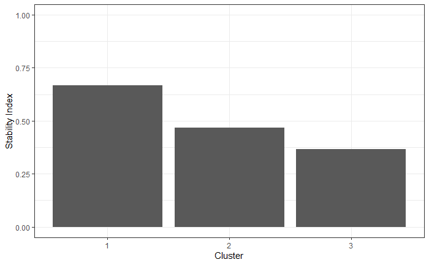

```r
sc3_plot_cluster_stability(sce, k = 3)
```

## DE genes

Differential expression is calculated using the non-parametric Kruskal-Wallis test. A significant p-value indicates that gene expression in at least one cluster stochastically dominates one other cluster. SC3 provides a list of all differentially expressed genes with adjusted p-values < 0.01 and plots gene expression profiles of the 50 genes with the lowest p-values. Note that the calculation of differential expression after clustering can introduce a bias in the distribution of p-values, and thus we advise to use the p-values for ranking the genes only.

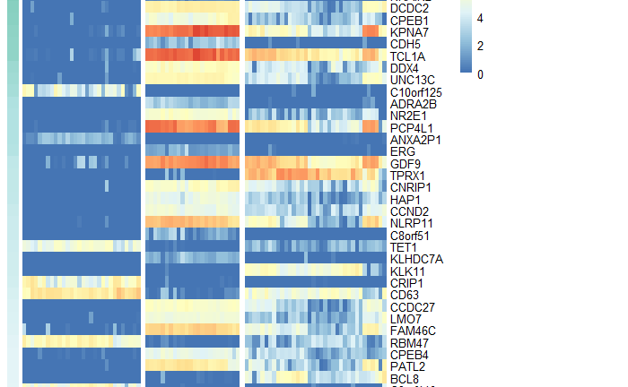

```r
sc3_plot_de_genes(sce, k = 3)
```

It is also possible to annotate cells (columns of the matrix containing DE genes) with any column of the colData slot of the sce object.

```
Provided columns 'log10_total_features' do not exist in the phenoData table!
```

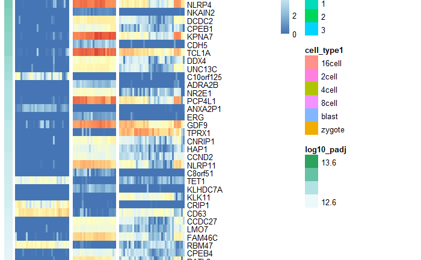

```r
sc3_plot_de_genes(
    sce, k = 3,
    show_pdata = c(
        "cell_type1",
        "log10_total_features",
        "sc3_3_clusters",
        "sc3_3_log2_outlier_score"
    )
)
```

## Marker Genes

To find marker genes, for each gene a binary classifier is constructed based on the mean cluster expression values. The classifier prediction is then calculated using the gene expression ranks. The area under the receiver operating characteristic (ROC) curve is used to quantify the accuracy of the prediction. A p-value is assigned to each gene by using the Wilcoxon signed rank test. By default the genes with the area under the ROC curve (AUROC) > 0.85 and with the p-value < 0.01 are selected and the top 10 marker genes of each cluster are visualized in this heatmap.

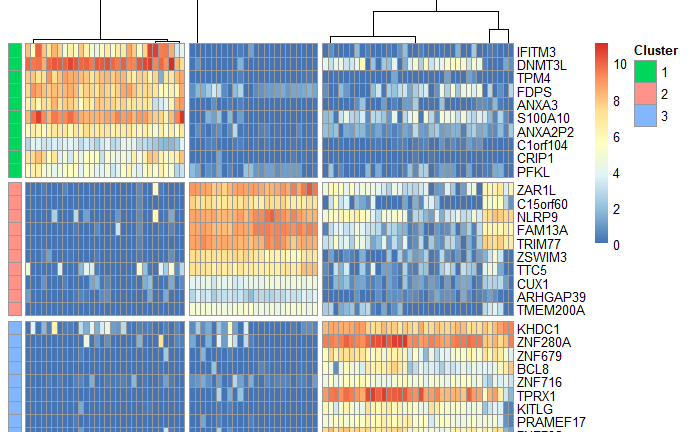

```r
sc3_plot_markers(sce, k = 3)
```

It is also possible to annotate cells (columns of the matrix containing marker genes) with any column of the colData slot of the sce object.

```
Provided columns 'log10_total_features' do not exist in the phenoData table!
```

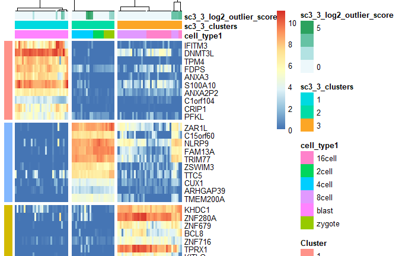

```r
sc3_plot_markers(
    sce, k = 3,
    show_pdata = c(
        "cell_type1",
        "log10_total_features",
        "sc3_3_clusters",
        "sc3_3_log2_outlier_score"
    )
)
```

# SC3 in Detail

The main sc3 method explained above is a wrapper that calls several other SC3 methods in the following order:

- sc3_prepare
- (optional) sc3_estimate_k
- sc3_calc_dists
- sc3_calc_transfs
- sc3_kmeans
- sc3_calc_consens
- (optional) sc3_calc_biology

Let us go through each of them independently.

## sc3_prepare

We start with sc3_prepare. This method prepares an object of sce class for SC3 clustering. This method also defines all parameters needed for clustering and stores them in the sc3 slot. The parameters have their own defaults but can be manually changed. For more information on the parameters please use ?sc3_prepare.

```r
sce <- sc3_prepare(sce)
```

```
Setting SC3 parameters...
There were 12 warnings (use warnings() to see them)
```

```r
str(metadata(sce)$sc3)
```

```
List of 5
 $ kmeans_iter_max: num 1e+09
 $ kmeans_nstart  : num 1000
 $ n_dim          : int [1:5] 3 4 5 6 7
 $ rand_seed      : num 1
 $ n_cores        : num 7
```

By default SC3 will use all but one cores of your machine. You can manually set the number of cores to be used by setting the n_cores parameter in the sc3_prepare call.

## (optional) sc3_estimate_k

When the sce object is prepared for clustering, SC3 can also estimate the optimal number of clusters k in the dataset. SC3 utilizes the Tracy-Widom theory on random matrices to estimate k. sc3_estimate_k method creates and populates the following items of the sc3 slot:

- k_estimation - contains the estimated value of k.

```r
sce <- sc3_estimate_k(sce)
```

```
Estimating k...
```

```r
str(metadata(sce)$sc3)
```

```
List of 6
 $ kmeans_iter_max: num 1e+09
 $ kmeans_nstart  : num 1000
 $ n_dim          : int [1:5] 3 4 5 6 7
 $ rand_seed      : num 1
 $ n_cores        : num 7
 $ k_estimation   : num 6
```

## sc3_calc_dists

Now we are ready to perform the clustering itself. First SC3 calculates distances between the cells. Method sc3_calc_dists calculates the distances, creates and populates the following items of the sc3 slot:

- distances - contains a list of distance matrices corresponding to Euclidean, Pearson and Spearman distances.

```r
sce <- sc3_calc_dists(sce)
```

```
Calculating distances between the cells...
```

```r
names(metadata(sce)$sc3$distances)
```

```
[1] "euclidean" "pearson"   "spearman"
```

## sc3_calc_transfs

Next the distance matrices are transformed using PCA and graph Laplacian. Method sc3_calc_transfs calculates transforamtions of the distance matrices contained in the distances item of the sc3 slot. It then creates and populates the following items of the sc3 slot:

- transformations - contains a list of transformations of the distance matrices corresponding to PCA and graph Laplacian transformations.

```r
sce <- sc3_calc_transfs(sce)
```

```
Performing transformations and calculating eigenvectors...
```

```r
names(metadata(sce)$sc3$transformations)
```

```
[1] "euclidean_pca"
[2] "pearson_pca"
[3] "spearman_pca"
[4] "euclidean_laplacian"
[5] "pearson_laplacian"
[6] "spearman_laplacian"
```

It also removes the previously calculated distances item from the sc3 slot:

```r
metadata(sce)$sc3$distances
```

## sc3_kmeans

kmeans should then be performed on the transformed distance matrices contained in the transformations item of the sc3 slot. Method sc3_kmeans creates and populates the following items of the sc3 slot:

- kmeans - contains a list of kmeans clusterings.

By default the nstart parameter passed to kmeans defined in sc3_prepare method, is set 1000 and written to kmeans_nstart item of the sc3 slot. If the number of cells in the dataset is more than 2,000, this parameter is set to 50. A user can also manually define this parameter by changing the value of the kmeans_nstart item of the sc3 slot.

```r
sce <- sc3_kmeans(sce, ks = 2:4)
```

```
Performing k-means clustering...
```

```r
names(metadata(sce)$sc3$kmeans)
```

```
 [1] "euclidean_pca_2_3"
 [2] "pearson_pca_2_3"
 [3] "spearman_pca_2_3"
 [4] "euclidean_laplacian_2_3"
 [5] "pearson_laplacian_2_3"
 [6] "spearman_laplacian_2_3"
 [7] "euclidean_pca_3_3"
 [8] "pearson_pca_3_3"
 [9] "spearman_pca_3_3"
[10] "euclidean_laplacian_3_3"
[11] "pearson_laplacian_3_3"
[12] "spearman_laplacian_3_3"
[13] "euclidean_pca_4_3"
[14] "pearson_pca_4_3"
[15] "spearman_pca_4_3"
```

[output cut: 75 more lines]

## sc3_calc_consens

In this step SC3 will provide you with a clustering solution. Let’s first check that there are no SC3 related columns in the colData slot:

```r
col_data <- colData(sce)
head(col_data[ , grep("sc3_", colnames(col_data))])
```

```
DataFrame with 6 rows and 0 columns
```

When calculating consensus for each value of k SC3 averages the clustering results of kmeans using a consensus approach. Method sc3_calc_consens calculates consensus matrices based on the clustering solutions contained in the kmeans item of the sc3 slot. It then creates and populates the following items of the sc3 slot:

- consensus - for each value of k it contains: a consensus matrix, an hclust object, corresponding to hierarchical clustering of the consensus matrix and the Silhouette indeces of the clusters.

```r
sce <- sc3_calc_consens(sce)
```

```
Calculating consensus matrix...
```

```r
names(metadata(sce)$sc3$consensus)
```

```
[1] "2" "3" "4"
```

```r
names(metadata(sce)$sc3$consensus$`3`)
```

```
[1] "consensus"  "hc"         "silhouette"
```

It also removes the previously calculated kmeans item from the sc3 slot:

```r
metadata(sce)$sc3$kmeans
```

As mentioned before all the clustering results (cell-related information) are written to the colData slot of the sce object:

```r
col_data <- colData(sce)
head(col_data[ , grep("sc3_", colnames(col_data))])
```

```
DataFrame with 6 rows and 3 columns
                sc3_2_clusters
                      <factor>
Oocyte..1.RPKM.              2
Oocyte..2.RPKM.              2
Oocyte..3.RPKM.              2
Zygote..1.RPKM.              2
Zygote..2.RPKM.              2
Zygote..3.RPKM.              2
                sc3_3_clusters
                      <factor>
Oocyte..1.RPKM.              2
Oocyte..2.RPKM.              2
Oocyte..3.RPKM.              2
Zygote..1.RPKM.              2
Zygote..2.RPKM.              2
Zygote..3.RPKM.              2
                sc3_4_clusters
                      <factor>
Oocyte..1.RPKM.              2
Oocyte..2.RPKM.              2
Oocyte..3.RPKM.              2
Zygote..1.RPKM.              2
Zygote..2.RPKM.              2
Zygote..3.RPKM.              2
```

We can see that SC3 calculated clusters for k = 2, 3 and 4 and wrote them to the colData slot of the sce object.

## (optional) sc3_calc_biology

SC3 can also calculates DE genes, marker genes and cell outliers based on the calculated consensus clusterings. Similary to the clustering solutions, method sc3_calc_biology writes the results for the cell outliers (cell-related information) to the colData slot of the sce object. In contrast, DE and marker genes results (gene-related information) is are written to the rowData slot. In addition biology item of the sc3 slot is set to TRUE.

```r
sce <- sc3_calc_biology(sce, ks = 2:4)
```

```
Calculating biology...
```

### Cell Outliers

Now we can see that cell outlier scores have been calculated for each value of k:

```r
col_data <- colData(sce)
head(col_data[ , grep("sc3_", colnames(col_data))])
```

```
DataFrame with 6 rows and 6 columns
                sc3_2_clusters
                      <factor>
Oocyte..1.RPKM.              2
Oocyte..2.RPKM.              2
Oocyte..3.RPKM.              2
Zygote..1.RPKM.              2
Zygote..2.RPKM.              2
Zygote..3.RPKM.              2
                sc3_3_clusters
                      <factor>
Oocyte..1.RPKM.              2
Oocyte..2.RPKM.              2
Oocyte..3.RPKM.              2
Zygote..1.RPKM.              2
Zygote..2.RPKM.              2
Zygote..3.RPKM.              2
                sc3_4_clusters
                      <factor>
Oocyte..1.RPKM.              2
Oocyte..2.RPKM.              2
Oocyte..3.RPKM.              2
Zygote..1.RPKM.              2
Zygote..2.RPKM.              2
Zygote..3.RPKM.              2
                sc3_2_log2_outlier_score
                               <numeric>
Oocyte..1.RPKM.                        0
Oocyte..2.RPKM.                        0
Oocyte..3.RPKM.                        0
Zygote..1.RPKM.                        0
Zygote..2.RPKM.                        0
Zygote..3.RPKM.                        0
                sc3_3_log2_outlier_score
                               <numeric>
Oocyte..1.RPKM.                  2.79513
Oocyte..2.RPKM.                  2.83115
Oocyte..3.RPKM.                  2.59279
Zygote..1.RPKM.                  0.00000
Zygote..2.RPKM.                  0.00000
Zygote..3.RPKM.                  0.00000
                sc3_4_log2_outlier_score
                               <numeric>
Oocyte..1.RPKM.                  2.79513
Oocyte..2.RPKM.                  2.83115
Oocyte..3.RPKM.                  2.59279
Zygote..1.RPKM.                  0.00000
Zygote..2.RPKM.                  0.00000
Zygote..3.RPKM.                  0.00000
```

For more information on how the cell outliers are calculated please see ?get_outl_cells.

### DE and marker genes

We can also see that DE and marker genes characteristics (adjusted p-values and area under the ROC curve) have been calculated for each value of k

```r
row_data <- rowData(sce)
head(row_data[ , grep("sc3_", colnames(row_data))])
```

```
DataFrame with 6 rows and 13 columns
         sc3_gene_filter
               <logical>
C9orf152           FALSE
RPS11              FALSE
ELMO2               TRUE
CREB3L1             TRUE
PNMA1              FALSE
MMP2                TRUE
         sc3_2_markers_clusts
                    <numeric>
C9orf152                   NA
RPS11                      NA
ELMO2                       2
CREB3L1                     2
PNMA1                      NA
MMP2                        1
         sc3_2_markers_padj
                  <numeric>
C9orf152                 NA
RPS11                    NA
ELMO2           3.43043e-06
CREB3L1         1.00000e+00
PNMA1                    NA
MMP2            1.00000e+00
         sc3_2_markers_auroc
                   <numeric>
C9orf152                  NA
RPS11                     NA
ELMO2               0.905833
CREB3L1             0.635833
PNMA1                     NA
MMP2                0.549722
         sc3_3_markers_clusts
                    <numeric>
C9orf152                   NA
RPS11                      NA
ELMO2                       2
CREB3L1                     2
PNMA1                      NA
```

[output cut: 42 more lines]

```
             <numeric>     <numeric>
C9orf152            NA            NA
RPS11               NA            NA
ELMO2      3.33801e-06   7.88682e-10
CREB3L1    1.00000e+00   2.03905e-03
PNMA1               NA            NA
MMP2       1.00000e+00   1.00000e+00
         sc3_4_de_padj
             <numeric>
C9orf152            NA
RPS11               NA
ELMO2      1.86624e-09
CREB3L1    6.16236e-03
PNMA1               NA
MMP2       1.00000e+00
```

For more information on how the DE and marker genes are calculated please see ?get_de_genes and ?get_marker_genes.